# Introduction to PRTree

## Overview

**PRTree** implements **Probabilistic Regression Trees (PRTrees)** in R with a high-performance **Fortran** backend. Unlike classical regression trees (such as CART), which partition the predictor space using hard binary splits and yield piecewise-constant predictions, PRTrees assign observations to terminal regions smoothly via probability distributions, producing continuous regression surfaces.

A key feature of **PRTree** is its built-in support for **missing predictor values (`NA`)** during both model fitting and prediction, without requiring prior imputation.

For the theoretical foundations of PRTrees with missing data, see Prass, Neimaier, & Pumi (2026), *Applied Mathematical Modelling*, 117450 (https://doi.org/10.1016/j.apm.2026.117450). For comprehensive implementation details and usage examples, see Prass, Neimaier, & Pumi (2025), arXiv:2510.03634 (https://doi.org/10.48550/arXiv.2510.03634).

```r
library(PRTree)
```

## 1. Fitting a Probabilistic Regression Tree

We start with a simple one-dimensional regression problem where the true signal is $f(x) = \cos(x)$ observed with Gaussian noise.

```r
set.seed(1234)
X <- matrix(runif(200, 0, 10), ncol = 1)
y <- cos(X[, 1]) + rnorm(200, 0, 0.08)

# Fit a PRTree using all observations for training (prop_hold = 0)
fit <- pr_tree(y, X, max_terminal_nodes = 9, prop_hold = 0)
summary(fit)
```

```
#>
#> ========================================================
#> Summary of Probabilistic Regression Tree (PRTree)
#> ========================================================
#> Number of observations: 200
#> Number of features: 1
#> Number of terminal nodes: 8
#> Distribution: norm
#> Fill type: 2
#>
#> Mean Squared Error:
#>   Train: 0.006051
#>   Validation: 0.000000
#>   Global: 0.006051
#>
#> Selected sigma:
#>   5.7760
#>
#> Terminal node statistics:
#>  node     gamma  P_mean     P_sd   P_min   P_q25 P_median   P_q75   P_max
#>     1     -1182 0.29456 0.162302 0.07697 0.15144  0.27374 0.43259 0.61291
#>     2      1301 0.30971 0.160608 0.07313 0.15958  0.28623 0.44602 0.60248
#>     3  55984681 0.05133 0.005906 0.03673 0.04723  0.05344 0.05635 0.05781
#>     4 -17862146 0.04073 0.010029 0.01917 0.03255  0.04435 0.04935 0.05028
#>     5  51722899 0.05586 0.010839 0.03038 0.04827  0.06077 0.06441 0.06577
#>     6 -95218723 0.04750 0.006947 0.02983 0.04427  0.04987 0.05294 0.05420
#>     7  -4128892 0.15726 0.021828 0.10408 0.14555  0.16086 0.17699 0.18090
#>     8   3170931 0.04304 0.010515 0.02167 0.03425  0.04717 0.05247 0.05437
#> ========================================================
```

Unlike standard regression trees, the fitted curve is smooth across split thresholds:

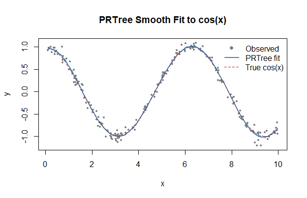

```r
ord <- order(X[, 1])
plot(
  X[ord, 1], y[ord],
  pch = 16, cex = 0.6, col = "gray50",
  xlab = "x", ylab = "y",
  main = "PRTree Smooth Fit to cos(x)"
)
lines(X[ord, 1], fit$yhat[ord], col = "steelblue", lwd = 2)
lines(X[ord, 1], cos(X[ord, 1]), col = "firebrick", lwd = 1.5, lty = 2)
legend(
  "topright",
  legend = c("Observed", "PRTree fit", "True cos(x)"),
  col = c("gray50", "steelblue", "firebrick"),
  pch = c(16, NA, NA), lty = c(NA, 1, 2), lwd = c(NA, 2, 1.5),
  bty = "n"
)
```

### Tree structure and diagnostic plots

`plot_tree()` displays the learned split hierarchy along with probability heatmaps at each terminal node (using base R graphics):

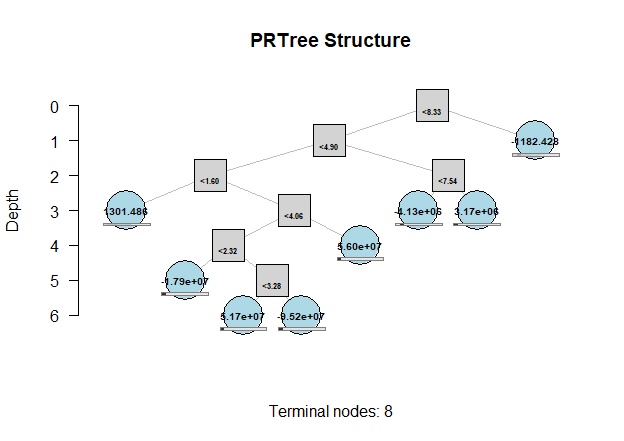

```r
plot_tree(fit, max_bins = 10)
```

When `ggplot2` is installed, `plot(fit, y)` produces model diagnostic panels (Observed vs. Fitted, Residuals, Q-Q plot, and Terminal Node Probabilities):

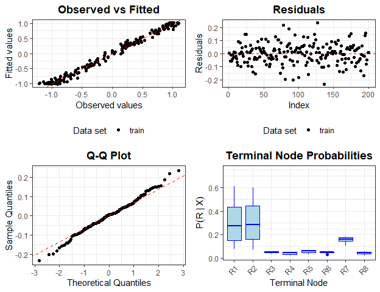

```r
plot(fit, y, which = c(1, 2, 4, 5), ncol = 2)
```

### Prediction on new data

Use `predict()` to obtain point predictions (`complete = FALSE`, the default) or both predictions and the terminal-node membership probability matrix `P` (`complete = TRUE`):

```r
X_new <- matrix(c(1.0, 3.14, 6.28, 9.0), ncol = 1)
pred <- predict(fit, newdata = X_new, complete = TRUE)

round(pred$yhat, 4)
```

```
#> [1]  0.5717 -0.9948  1.0170 -0.9399
```

```r
round(rowSums(pred$P), 6)
```

```
#> [1] 1 1 1 1
```

## 2. Controlling Smoothing Parameters and Distributions

Model parameters can be configured via `pr_tree_control()` or passed directly through `...` in `pr_tree()`.

By default, `pr_tree()` automatically constructs a grid of candidate smoothing parameters (`sigma`) scaled to the standard deviation of each predictor and selects the best vector on a holdout validation split (`prop_hold = 0.2`). You can also inspect or customize this grid using `expand_sigma_grid()`, or fix `sigma_grid` to a scalar, vector, or custom matrix:

```r
set.seed(42)
X2 <- matrix(runif(200 * 2, 0, 10), ncol = 2)
colnames(X2) <- c("x1", "x2")
y2 <- sin(X2[, 1]) + 0.4 * X2[, 2] + rnorm(200, 0, 0.15)

# Inspect an automatically scaled sigma grid
grid <- expand_sigma_grid(X2, grid_size = 5, tiny_sigma = 1e-20, verbose = FALSE)
grid
```

```
#>
#> ========================================================
#> Sigma Grid
#> ========================================================
#> Grid size: 6 candidates (5 + 1 tiny)
#> Features: 2
#>
#> First 5 rows:
#>                  x1         x2
#> 1          1.00e-20   1.00e-20
#> 2            1.1681     1.1705
#> 3            2.3362     2.3410
#> 4            3.5043     3.5116
#> 5            4.6724     4.6821
#> ... (1 more rows)
#> ========================================================
```

```r
# Fit using Student's t distribution (df = 4) and the custom grid
ctrl <- pr_tree_control(
  dist = "t",
  df = 4,
  sigma_grid = grid,
  max_terminal_nodes = 8,
  prop_hold = 0.2
)
fit_t <- pr_tree(y2, X2, control = ctrl)
fit_t
```

```
#>
#> ========================================================
#> Probabilistic Regression Tree (PRTree)
#> ========================================================
#> Number of observations: 200
#> Number of features: 2
#> Number of terminal nodes: 6
#> Distribution: t
#>   with df = 4.0000
#>
#> Mean Squared Error:
#>   Train: 0.403950
#>   Validation: 0.414891
#>   Global: 0.406138
#>
#> Selected sigma:
#>    3.5043, 3.5116
#> ========================================================
```

Setting `sigma_grid = 0` recovers crisp (hard-split) behavior while expanding automatically to match the number of predictors in `X`:

```r
ctrl_crisp <- pr_tree_control(sigma_grid = 0, prop_hold = 0, max_terminal_nodes = 6)
fit_crisp <- pr_tree(y2, X2, control = ctrl_crisp)
fit_crisp$sigma
```

```
#> [1] 0 0
```

## 3. Native Handling of Missing Data (`NA`)

**PRTree** handles missing predictor values directly during tree construction and prediction without prior imputation. Two parameters control this behavior:

- `proxy_crit` (`"mean"`, `"var"`, or `"both"`): criterion used to assign incomplete observations during node splits.
- `fill_type` (`0`, `1`, or `2`): strategy used to compute terminal-node membership probabilities `P` for observations with `NA` entries:
  - `0`: uniform probability across terminal regions;
  - `1`: probability 1 if all observed predictors fall within the region;
  - `2` (default): probability computed using only the observed predictors.

```r
set.seed(2026)
X_miss <- X2
X_miss[sample(nrow(X_miss), 25), 1] <- NA
X_miss[sample(nrow(X_miss), 20), 2] <- NA

# Compare the three missing-data probability strategies
mse_by_fill <- sapply(0:2, function(ft) {
  m <- pr_tree(
    y2, X_miss,
    fill_type = ft,
    proxy_crit = "both",
    max_terminal_nodes = 8,
    prop_hold = 0.2,
    grid_size = 4
  )
  m$mse["validation"]
})
names(mse_by_fill) <- paste0("fill_type=", 0:2)
round(mse_by_fill, 4)
```

```
#> fill_type=0 fill_type=1 fill_type=2
#>      0.4002      0.6990      0.5155
```

Predictions also work seamlessly when `newdata` contains partial or complete rows of `NA`:

```r
fit_na <- pr_tree(
  y2, X_miss,
  fill_type = 2,
  max_terminal_nodes = 8,
  prop_hold = 0,
  grid_size = 4
)

X_new_na <- rbind(
  c(2.0, 5.0),
  c(NA, 5.0),
  c(2.0, NA),
  c(NA, NA)
)
colnames(X_new_na) <- colnames(X2)

predict(fit_na, newdata = X_new_na)
```

```
#> [1] 2.134978 2.134978 2.386236 2.386236
```

## 4. Cross-Validation and Data Splitting

`train_test_split()` creates simple random splits, missing-value stratified splits, or *k*-fold partitions:

```r
set.seed(123)
is_na_row <- apply(is.na(X_miss), 1, any)
folds <- train_test_split(stratify = TRUE, is_NA = is_na_row, n_rep = 5)
summary(folds)
```

```
#>
#> ========================================================
#> K-fold Partition Summary
#> ========================================================
#> Sampling method: Stratified (by missing values)
#> Total observations: 200
#> Number of folds: 5
#>
#> --- Fold Statistics ---
#>  Fold Size Missing Missing (%)
#>     1   41       9       22.0%
#>     2   40       8       20.0%
#>     3   40       8       20.0%
#>     4   40       8       20.0%
#>     5   39       8       20.5%
#> ========================================================
```

`pr_tree_cv()` automates both **Monte Carlo** (`method = "montecarlo"`) and *k*-fold (`method = "kfold"`) cross-validation, including internal validation for selecting `sigma` and refitting on the full training folds (`update_final = TRUE`):

```r
set.seed(123)
ctrl_cv <- pr_tree_control_cv(
  method = "kfold",
  n_rep = 5,
  prop_valid = 0.2,
  stratify = TRUE,
  max_terminal_nodes = 6,
  grid_size = 3
)

cv_res <- pr_tree_cv(y2, X_miss, control_cv = ctrl_cv, verbose = FALSE)
summary(cv_res)
```

```
#>
#> ========================================================
#> Summary of PRTree Cross-Validation
#> ========================================================
#> Cross-Validation Configuration:
#>   Method: 5-fold CV
#>   Test set: 1 fold per iteration (~20.0% of data).
#>   Validation (for sigma): 0.20 of the training folds.
#>   Features: 2
#>   Stratification: TRUE
#>
#> --- RMSE Summary ---
#> Validation Set (used for sigma selection):
#>        Min        Q1    Median      Mean        Q3       Max         SD N
#>  0.7165538 0.7424459 0.7895829 0.7922058 0.8066387 0.9058076 0.07300658 5
#>
#> Test Set (unseen data):
#>        Min       Q1    Median      Mean        Q3       Max        SD N
#>  0.7022832 0.712286 0.8733391 0.8323491 0.9087283 0.9651092 0.1188187 5
#>
#> --- Selected Sigma Summary (by feature) ---
#>         Min     Mean   Median      Max       SD
#> x1 1.954499 4.308286 3.959845 5.893186 1.628666
#> x2 1.905049 4.223338 3.837079 5.858242 1.656737
#> ========================================================
```

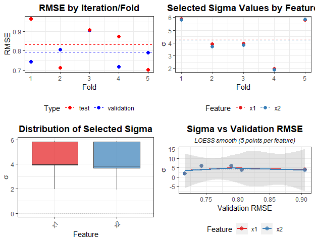

```r
plot(cv_res)
```

## References

- Alkhoury, S., Devijver, E., Clausel, M., Tami, M., Gaussier, E., & Oppenheim, G. (2020). Smooth and Consistent Probabilistic Regression Trees. *Advances in Neural Information Processing Systems (NeurIPS)*, 33, 11345–11355.
- Prass, T. S., Neimaier, A. S., & Pumi, G. (2026). Handling Missing Data in Probabilistic Regression Trees. *Applied Mathematical Modelling*, 117450. https://doi.org/10.1016/j.apm.2026.117450
- Prass, T. S., Neimaier, A. S., & Pumi, G. (2025). PRTree: An R Package for Probabilistic Regression Trees with Built-in Missing Data Handling. *arXiv:2510.03634*. https://doi.org/10.48550/arXiv.2510.03634